# What we talk about when we talk about innovation in Agriculture

Renan Magalhães

20/01/2022

This work intends to create the first attempt using text analysis tools while working with a database of studies related to innovation in agriculture. The objective here is to write the coding structure and apply it to a developing database, later advancing to a larger one, replicating the procedures developed here. In this way, I wrote the code so that it is possible to apply it in other databases without the necessity of significant changes.

Considering the ERC proposal’s intentions to understand the broad impacts of innovation in the agriculture sector, this work seeks to help in the definition of innovation within the field - what is considered innovation by different studies, its effects, applications and, mainly, what type of impact is mainly being measured. The analysis tries to give tools and assist in answering questions such as:

- What types of studies are being done?
- Which methodologies are being used mainly? What do they assess?
- Is innovation mostly considered technological or governance processes? What are these technologies or policies?
- What kind of result is expected from applying these innovations: productivity gains, the reduction of GHG emissions, or possibly an advance in the social conditions of agricultural workers?
- And finally, is it possible to find a way to fully measure the impacts of innovation in agriculture, an assessment that addresses both environmental, social, and economic effects?

## Text Analysis: initial overview

First, we load the packages used in the data exploration.

```r
library(quanteda)
library(readtext)
library(readr)
library(tidyverse)
library(readxl)
library(wordcloud2)
library(quanteda.textplots)
library(quanteda.textstats)
library(ggplot2)
library(tufte)
library(kableExtra)
library(topicmodels)
library(LDAvis)
library(servr)
```

We upload the data in excel format.

```r
text <- read_excel("C:/Users/Airton/OneDrive/Documentos/texto.xlsx")
```

To proceed with the text analysis, we must convert texts to a Corpus format (transforming the text into different tokens) and DFM (Matrixes that quantify how many times each word was used, allowing analysis with the created objects). We can also remove stopwords (is, can, it, etc.) and the punctuation for a cleaner data analysis.

```r
text_corpus <- corpus(text, text_field = "Abstract")
text_dfm <- dfm(text_corpus, stem = TRUE, remove = stopwords("en"), remove_punct = TRUE)

text_corpus
```

```
## Corpus consisting of 77 documents and 4 docvars.
## text1 :
## "ABSTRACT: Long term crop yield with various crop rotations i..."
##
## text2 :
## "<p>The USDA Northern Forests Climate Hub (NFCH) and the Fore..."
##
## text3 :
## "Background:: Cardoon is a multi-purpose crop with a wide spe..."
##
## text4 :
## "&lt;p&gt;&amp;#160;It has been widely reported that although..."
##
## text5 :
## "This study investigates the input–output energy-flow pattern..."
##
## text6 :
## "Crop selections and rotations are very important in optimisi..."
##
## [ reached max_ndoc ... 71 more documents ]
```

```r
text_dfm
```

```
## Document-feature matrix of: 77 documents, 2,280 features (96.49% sparse) and 4 docvars.
##        features
## docs    abstract long term crop yield various rotat irrig subsurfac drip
##   text1        1    1    1   12     7       1     8     8         1    3
##   text2        0    0    0    0     0       0     0     0         0    0
##   text3        0    0    0    1     0       0     0     4         0    4
##   text4        0    0    0    1     0       0     0     0         0    0
##   text5        0    0    0    3     0       0     1     0         0    0
##   text6        0    1    0   14     3       0     3     0         0    0
## [ reached max_ndoc ... 71 more documents, reached max_nfeat ... 2,270 more features ]
```

Then, we trim the data, considering the terms used in the articles at least ten times.

```r
text_dfm_trim <- dfm_trim(text_dfm, min_termfreq = 10)
text_dfm_trim
```

```
## Document-feature matrix of: 77 documents, 220 features (84.32% sparse) and 4 docvars.
##        features
## docs    abstract crop yield rotat irrig drip system soil two three
##   text1        1   12     7     8     8    3      1    1   1     2
##   text2        0    0     0     0     0    0      0    0   1     0
##   text3        0    1     0     0     4    4      0    1   0     1
##   text4        0    1     0     0     0    0      4    2   0     1
##   text5        0    3     0     1     0    0      2    0   0     1
##   text6        0   14     3     3     0    0      2    3   0     0
## [ reached max_ndoc ... 71 more documents, reached max_nfeat ... 210 more features ]
```

We can create a word cloud for an initial vision of this database’s most used terms and words.

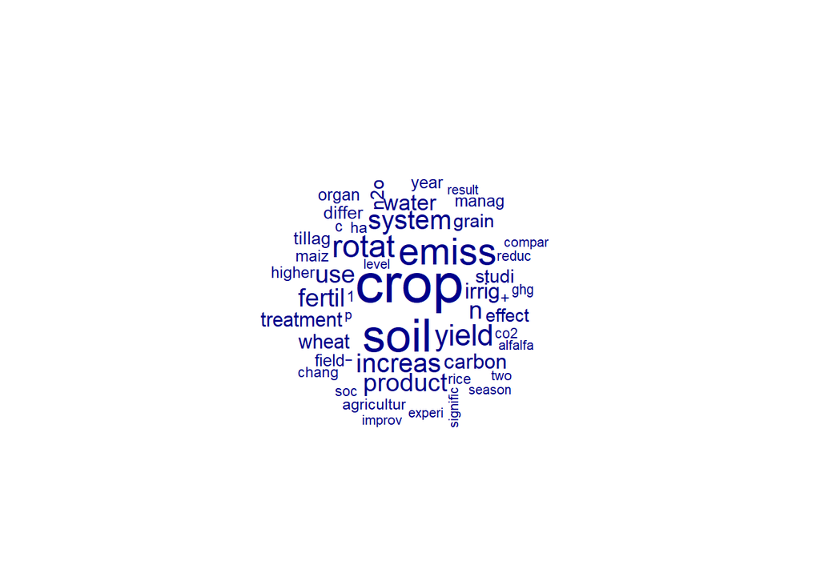

Wordcloud most frequent words in the database.

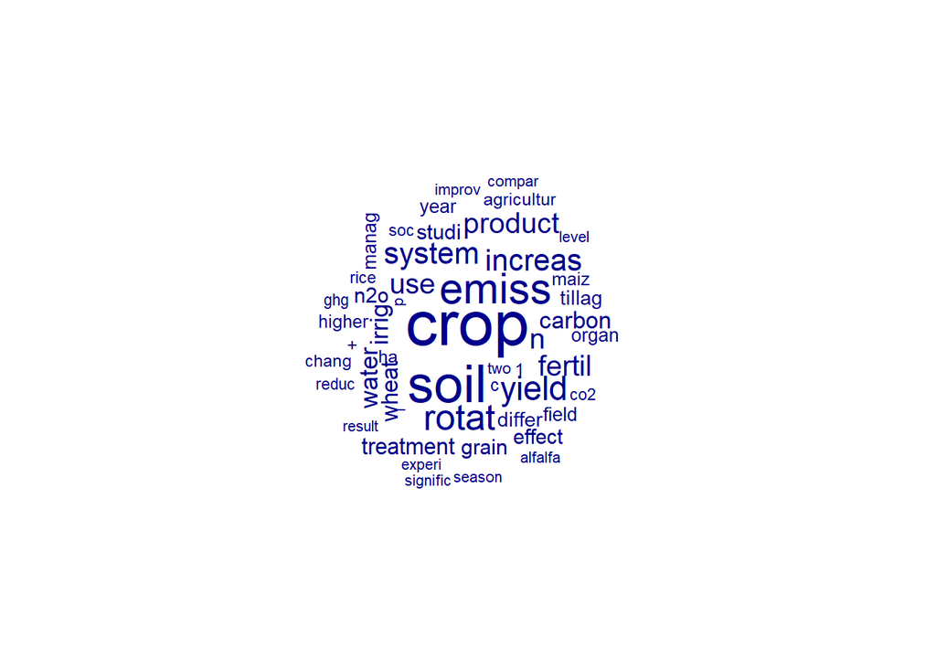

Wordcloud trimmed from the most frequent words in the database.

Here, we are quantifying the most frequent words.

```r
textstat_frequency(text_dfm_trim, n = 10)
```

```
##    feature frequency rank docfreq group
## 1     crop       228    1      54   all
## 2     soil       182    2      50   all
## 3    emiss       142    3      28   all
## 4    rotat       115    4      35   all
## 5    yield       106    5      37   all
## 6  increas        91    6      33   all
## 7   system        89    7      35   all
## 8      use        83    8      41   all
## 9        n        83    8      21   all
## 10  fertil        83    8      25   all
```

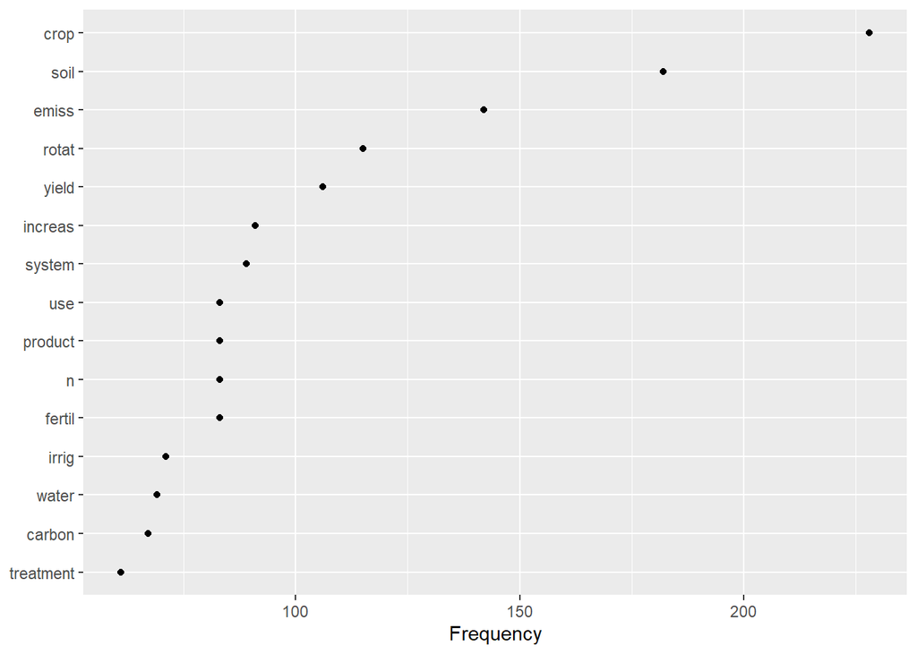

Plotting the most frequent words in the database

The preliminary analysis gives us an initial view of what these studies address, which technologies are being used, and what can be considered an innovation. For example, the studies looking at crop rotation, irrigation and fertilization techniques, and water use management are the ones most frequent. Through text collocation, looking at compound words and sentences, it is possible to make this observation more accurate.

```r
toks_adjusted <- text_corpus %>%
  tokens() %>%
  tokens_remove(pattern = stopwords("en")) %>%
  tokens_wordstem()
tstat_col_adjusted <- toks_adjusted %>%
  textstat_collocations(min_count = 5, tolower = FALSE)


head(tstat_col_adjusted, 15)
```

```
##     collocation count count_nested length   lambda        z
## 1    crop rotat    43            0      2 3.505580 16.40147
## 2     N2O emiss    36            0      2 5.798147 15.26062
## 3    crop yield    32            0      2 3.128400 13.61841
## 4  organ carbon    16            0      2 4.703946 13.33972
## 5           - 1    23            0      2 9.074499 13.00170
## 6    drip irrig    22            0      2 6.854261 12.68185
## 7  climat chang    11            0      2 5.947109 12.43199
## 8   grain yield    17            0      2 3.841975 12.26115
## 9    grain fill    14            0      2 6.073746 12.17384
## 10    fill rate     9            0      2 6.383356 11.90314
## 11 field experi    10            0      2 5.232328 11.84303
## 12          p >     9            0      2 7.333327 11.52519
## 13 straw return     9            0      2 6.731623 11.35050
## 14    GHG emiss    19            0      2 5.538905 11.23862
## 15       year -     8            0      2 5.192444 10.94912
```

```r
toks_comp <- toks_adjusted %>%
  tokens_compound(tstat_col_adjusted[tstat_col_adjusted$z > 3])

compound_tok <- toks_comp %>%
  tokens_keep(pattern = "*_*") %>%
  dfm() %>%
  topfeatures()

compound_tok
```

```
##     crop_rotat     crop_yield      n2o_emiss      ghg_emiss soil_n2o_emiss   crop_product    grain_yield     drip_irrig  greenhous_gas   nitrous_oxid
##             39             30             20             19             15             14             14             13             12             12
```

## Text Analysis: associated words and terms

At this stage of the work, we can look at the words that are associated with the word “innovation” and similar terms to understand what these studies talk about when they talk about innovation.

```r
innovation_kwic <- kwic(tokens(text_corpus), 'innovation', window = 10)
head(innovation_kwic, 10)
```

```
## Keyword-in-context with 4 matches.
##  [text63, 206]                 overall CO2 reduction. Placed at the intersection of technology | innovation | and the need to find more efficient ways to protect
##   [text68, 66]                 indirectly explored. Here we provide firm-level evidence of the | innovation | effect directly from China's pilot emissions trading, based on
##   [text68, 89] information and a quasi-experimental design. China's pilots increase low-carbon | innovation | of ETS firms by 5 - 10% without crowding
##  [text68, 104]                             5 - 10% without crowding out their other technology | innovation | . The increase from ETS firms accounts for about 1
```

```r
innovation <- kwic(tokens(text_corpus), 'innovati*')
innovation_corp <- corpus(innovation)
innovation_dfm <- innovation_corp |>
  tokens(remove_punct = T, remove_numbers = T, remove_symbols = T) |>
  tokens_tolower() |>
  tokens_remove(stopwords('en')) |>
  tokens_wordstem() |>
  dfm()

innovation
```

```
## Keyword-in-context with 4 matches.
##  [text63, 206]    at the intersection of technology | innovation | and the need to find
##   [text68, 66]   provide firm-level evidence of the | innovation | effect directly from China's pilot
##   [text68, 89] . China's pilots increase low-carbon | innovation | of ETS firms by 5
##  [text68, 104]  crowding out their other technology | innovation | . The increase from ETS
```

## Text Analysis: dictionary analysis

A dictionary analysis also allows us to have a more accurate observation of the objectives and interests from the different studies. From our initial research supporting the ERC proposal, it was possible to create three types of dictionaries to help us in the investigations:

- Dictionary of impact analysis associating terms for “environmental impact”, “social impact”, and “economic impact”;
- Dictionary of methodologies, associating terms to each type of industrial ecology methodology;
- Dictionary of innovations, differentiating technological innovation from governance innovation.

The analysis from the dictionaries allows us to make observations such as which methodologies are being most used in the studies, if the innovations fall mainly on the technical or governance innovation side, and understand the type of impact prioritized by these studies. However, the analysis here is incipient, and for better results, it is essential to apply it to full texts, not just the abstract. Also, dictionaries can be changed to add other terms and words if desired, in a process that ideally is built collectively.

### Dictionary 1

```r
dict <- dictionary(list(environmental = c('environment*','GHG','emission*','florest','burning'),
                        economy = c('econom*', 'tax*','profit','money', 'subsidy'),
                        social = c('social','gender', 'wages','job*','inequality','poverty')))
dict_dfm <- dfm_lookup(text_dfm, dict, exclusive=TRUE)
dict_dfm
```

```
## Document-feature matrix of: 77 documents, 3 features (86.15% sparse) and 4 docvars.
##        features
## docs    environmental economy social
##   text1             0       0      0
##   text2             1       0      0
##   text3             0       0      0
##   text4             7       0      0
##   text5             0       0      0
##   text6             0       0      0
## [ reached max_ndoc ... 71 more documents ]
```

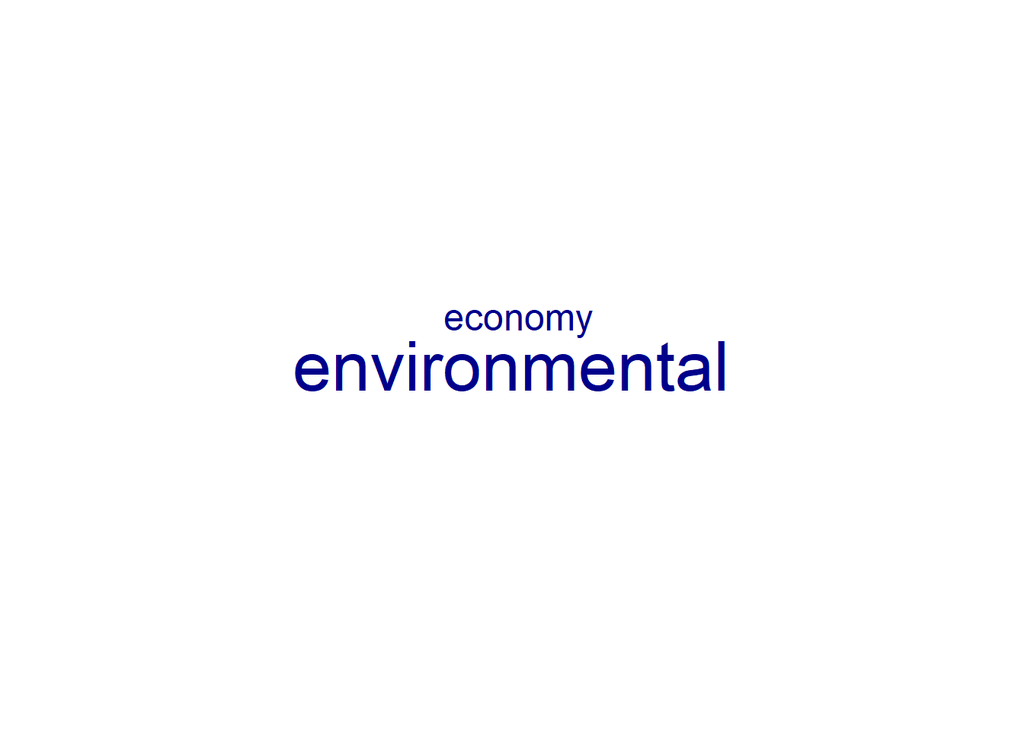

```r
textplot_wordcloud(dict_dfm)
```

### Dictionary 2

```r
dict_meto <- dictionary(list(LCA = c('Life Cycle Assessment', 'LCA', 'Life Cycle', 'cradle-to-grave', 'product life', 'LCI', 'inventory', 'LCIA'),
                             SLCA = c('jobs', 'accidents', 'wages', 'gender', 'education', 'working hours'),
                             MRIO = c('Trade network', 'trade', 'multi region', 'export', 'transaction'),
                             IO = c('input-output ratio'),
                             MFA = c('MFA', 'Material flow', 'waste', 'imput', 'output', 'transformation', 'flowchart'),
                             PLUM = c('Product land use', 'land use'),
                             EA = c('Energy Analysis', 'EA', 'energy *', 'imput', 'fuel', 'renewable'),
                             CBA = c('cost benefit', 'cost*', 'economic', 'cost', 'benefit', 'external cost', 'cost-benefit'),
                             EIA = c('Environmental Impact Assessment', 'participation', 'EIA', 'local level')))

dict_meto_dtm <- dfm_lookup(text_dfm, dict_meto, exclusive = TRUE)
dict_meto_dtm
```

```
## Document-feature matrix of: 77 documents, 9 features (98.27% sparse) and 4 docvars.
##        features
## docs    LCA SLCA MRIO IO MFA PLUM EA CBA EIA
##   text1   0    0    0  0   0    0  0   0   0
##   text2   0    0    0  0   0    0  0   1   0
##   text3   0    0    0  0   0    0  0   0   0
##   text4   0    0    0  0   0    0  0   0   0
##   text5   0    0    0  0   2    0  0   0   0
##   text6   0    0    0  0   0    0  0   0   0
## [ reached max_ndoc ... 71 more documents ]
```

[figure not shown]

```r
textplot_wordcloud(dict_meto_dtm)
```

### Dictionary 3

```r
dict_tech_or_gov <- dictionary(list(technology = c('living mulches', 'nutrient management', 'crop rotation', 'associated plants', 'agroforestry', 'intercropping', 'embedded natural', 'restoration', 'fodder cropping', 'rangeland improvement', 'fert*', 'sequestration','rotation', 'nutrient'),
                             governance = c('governance', 'policy', 'public policy', 'pay not burn', 'subsidy', 'tax*','regulation', 'behavior')))


dict_tech_or_gov_dtm <- dfm_lookup(text_dfm, dict_tech_or_gov, exclusive = TRUE)
dict_tech_or_gov_dtm
```

```
## Document-feature matrix of: 77 documents, 2 features (76.62% sparse) and 4 docvars.
##        features
## docs    technology governance
##   text1          0          0
##   text2          0          0
##   text3          6          0
##   text4          0          0
##   text5          0          0
##   text6          2          0
## [ reached max_ndoc ... 71 more documents ]
```

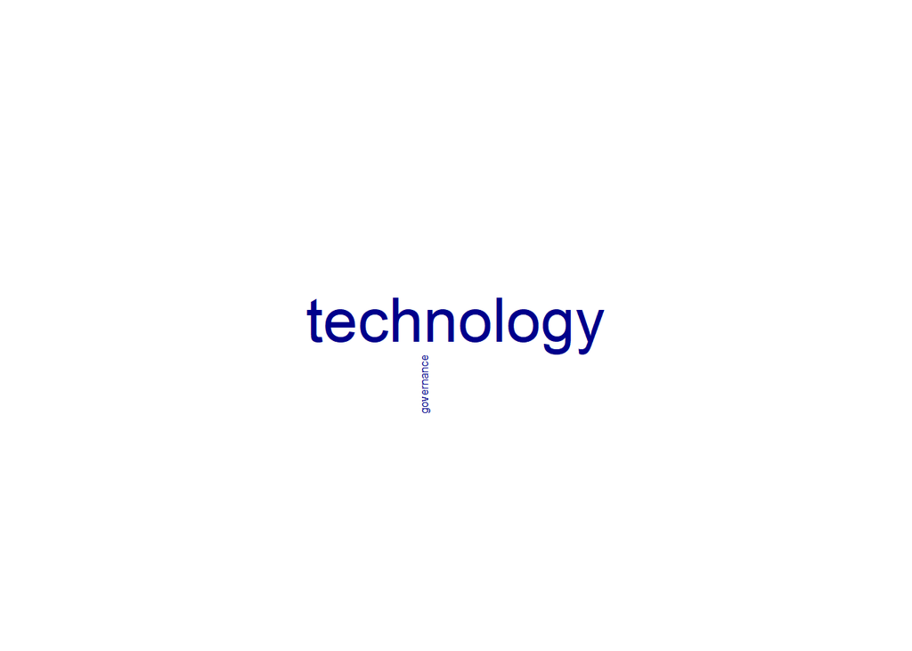

```r
textplot_wordcloud(dict_tech_or_gov_dtm)
```

```r
env_kwic <- kwic(text_corpus, dict$environmental, window = 3)
eco_kwic <- kwic(text_corpus, dict$economy, window = 3)

head(env_kwic, 20)
```

```
## Keyword-in-context with 20 matches.
##   [text2, 86]     Finding USDA Programmatic |    GHG    | Mitigation Opportunities )
##   [text3, 41]       irrigation practices on | emissions | of nitrous oxide
##   [text4, 50]              greenhouse gas ( |    GHG    | ) emissions from
##   [text4, 52]                       ( GHG ) | emissions | from crop production
##   [text4, 75]         than evaluating these | emissions | in isolation.
##  [text4, 112]       management practices on |    GHG    | emissions at the
##  [text4, 113]              practices on GHG | emissions | at the whole
##  [text4, 139]      mitigation of farm-level |    GHG    | emissions. Ideally
##  [text4, 140]             of farm-level GHG | emissions | . Ideally,
##  [text4, 154]     performance in predicting |    GHG    | emissions in future
##  [text4, 155]             in predicting GHG | emissions | in future climatic
##  [text4, 187]                         & gt; | emissions | but the accuracy
##  [text4, 239]                         ; O ) | emissions | is quite low
##  [text4, 252]         prominent drivers for |    GHG    | emissions in a
##  [text4, 253]               drivers for GHG | emissions | in a whole
##  [text4, 301]                         gt; O | emissions | from soil management
##  [text4, 356]                         gt; O | emissions | in whole-farm models
##  [text4, 365]       substantial errors into |    GHG    | inventories and lead
##  [text4, 430] uncertainties associated with | emissions | of CH&
##  [text4, 475]     for reported agricultural | emissions | requiring uncertainty or
```

```r
head(eco_kwic, 20)
```

```
## Keyword-in-context with 17 matches.
##    [text9, 87]              vital role in | economizing | irrigation water,
##   [text13, 41]            high energy and |  economic   | efficiency in the
##    [text15, 6]             and technical, |  economic   | and environmental issues
##   [text23, 28]               in the world |   economy   | continues to grow
##   [text25, 74]             to the overall |   economy   | and sustainable development
##   [text35, 23]              across sites. |  Economics  | and greenhouse gases
##   [text35, 56]     appraise productivity, |  economics  | and GHGs emissions
##  [text42, 218]       bacterial and fungal |    taxa     | , whereas continuous
##  [text54, 163]              . A bacterial |    taxon    | in family
##    [text73, 8]          context of carbon | tax-subsidy | policy, our
##   [text73, 34]          impacts of carbon | tax-subsidy | policy on the
##  [text73, 102]                   ii ) the |  taxation   | intensity coefficient accelerates
##  [text73, 151] implement effective carbon | tax-subsidy | policy on manufacturers
##  [text74, 119]    where highly productive |    taxa     | were tested,
##  [text74, 145]                 ) of these |    taxa     | yield about 12
##  [text74, 245]     resulting in favorable |  economic   | , energy and
##  [text74, 260]      plantations can bring |  economic   | and environmental gains
```

This overview allows us to understand what is being addressed when dealing with innovation. The preliminary use of this database shows us that the studies mainly focus on analyzing the environmental impact, with a low incidence of innovation processes aimed at measuring the economic impact - and without any study that investigates the social impact isolated. Likewise, we see studies analyzing the impact of technologies are much more present than studies on governance impact. From this preliminary view, it is critical to replicate the data to a more extensive database and see if these considerations repeat.

## Text Analysis: Topic Modeling

A topic model is a textual statistical analysis used to extract “topics” within a collection of documents, creating patterns within a set of topics. With supervised human analysis, it is possible to understand the frequently associated terms with the same set. This allows us to observe, for example, the terms associated with each methodology or the terms associated with each type of innovation. Through the packages **topicmodels()**, **LDAvis()** and **servr()** we build the topics.

Here we present the topics and a list of 5 words associated with them:

```r
text_dtm_topic <- convert(text_dfm_trim, to = "topicmodels")

set.seed(123)
m <- LDA(text_dfm_trim, method = "Gibbs", k = 10,  control = list(alpha = 0.1))
m
```

```
## A LDA_Gibbs topic model with 10 topics.
```

```r
terms(m, 5)
```

```
##      Topic 1  Topic 2  Topic 3 Topic 4   Topic 5   Topic 6      Topic 7   Topic 8 Topic 9  Topic 10
## [1,] "soil"   "crop"   "emiss" "crop"    "irrig"   "soil"       "grain"   "model" "use"    "n"
## [2,] "crop"   "yield"  "n2o"   "rotat"   "water"   "agricultur" "fill"    "<"     "carbon" "fertil"
## [3,] "tillag" "wheat"  "soil"  "alfalfa" "crop"    "nutrient"   "increas" "lt"    "emiss"  "treatment"
## [4,] "maiz"   "grain"  "1"     "soil"    "drip"    "increas"    "varieti" "gt"    "chang"  "+"
## [5,] "system" "fertil" "-"     "wheat"   "product" "practic"    "rate"    "sub"   "land"   "npk"
```

We can also analyze the most frequent words of each topic individually. Here is a look at topic 9:

```r
topic <- 9
words <- posterior(m)$terms[topic, ]
topwords <- head(sort(words, decreasing = T), n=50)
head(topwords)
```

```
##        use     carbon      emiss      chang       land      total
## 0.05280136 0.04940577 0.04940577 0.03752122 0.03582343 0.03412564
```

```r
topic.docs <- posterior(m)$topics[, topic]
topic.docs <- sort(topic.docs, decreasing=T)
head(topic.docs)
```

```
##    text63    text18    text71     text5    text73    text45
## 0.9390625 0.9289855 0.8763889 0.7247619 0.7178571 0.6200000
```

Finally, we can visualize the characteristics of each topic, such as the proximity between them, interactively.

```r
dtm <- text_dtm_topic

dtm = dtm[slam::row_sums(dtm) > 0, ]
phi = as.matrix(posterior(m)$terms)
theta <- as.matrix(posterior(m)$topics)
vocab <- colnames(phi)
doc.length = slam::row_sums(dtm)
term.freq = slam::col_sums(dtm)[match(vocab, colnames(dtm))]

json = createJSON(phi = phi, theta = theta, vocab = vocab,
                  doc.length = doc.length, term.frequency = term.freq)
serVis(json, out.dir = tempfile(), open.browser = interactive(), as.gist = FALSE)
```

The use of topic modeling also helps us build more robust dictionaries, allowing more accurate analysis.

## Next steps

Through topic modeling and dictionaries, it is possible to create an application that individually defines the methodology used by each paper. From this, it is possible to associate terms for each method. Until now, the code was applied only in the article’s abstract, so the following visualization has no value, being just an experiment. However, when considering the whole text body, it has the potential to connect the terms inside each topic to each methodology. Likewise, this product can be replicated to understand each type of innovation and impact analysis, understanding what processes are mostly connected to each type of impact analysis or each type of innovation process.

```r
experimental_database <- read_excel("C:/Users/Airton/OneDrive/Documentos/experimento.xlsx")

text_corpus_exp <- corpus(experimental_database, text_field = "Abstract")
text_dtm_exp<- dfm(text_corpus_exp, stem = TRUE, remove = stopwords("en"), remove_punct = TRUE)
text_dtm_trim_exp <- dfm_trim(text_dtm_exp, min_termfreq = 10)

text_dtm_topic_exp <- convert(text_dtm_trim_exp, to = "topicmodels")

set.seed(123)

e <- LDA(text_dtm_trim_exp, method = "Gibbs", k = 10,  control = list(alpha = 0.1))
e
```

```
## A LDA_Gibbs topic model with 10 topics.
```

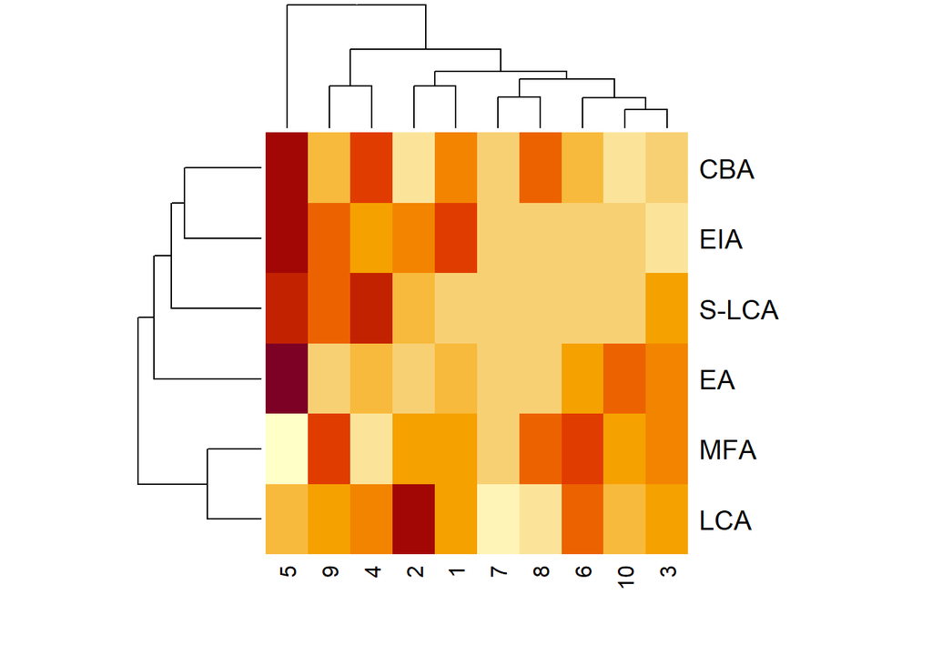

```r
docs <- docvars(text_dtm_trim_exp)[match(rownames(text_dtm_topic_exp), docnames(text_dtm_trim_exp)),]
tpp <- aggregate(posterior(e)$topics, by=docs["Methodology"], mean)
rownames(tpp) = tpp$Methodology
heatmap(as.matrix(tpp[-1]))
```